# Milestone Project for Coursera Data Science Specialization

Manil Wagle

December 25, 2015

# Introduction

This project is part of coursera data science specialization capstone course. The report aims to conduct and present findings of some of the basic exploratory analysis conducted on the data that was provided through SwiftKey. The overall goal of the project is to develop an application that can predict the next word that the user is likely to type to complete the sentence. The datasets provided for the project consists of 3 different text files namely (news, blogs and twitter). The exploratory analysis focuses on these three files. The report can be boken down into 5 parts: Data Collection, Data Pre Summary, Tokenization, Exploratory Analysis and Conclusions. Finally some of the consideration for the development of application will be highlighted.This report will present Some of the codes while some are summarized keeping in mind the space limitations. For detail codes on the project, please visit my github repository https://github.com/manilwagle/DataScienceMilestoneProject.

# Data Collection

The data were downloaded from the link that was provided through course website https://d396qusza40orc.cloudfront.net/dsscapstone/dataset/Coursera-SwiftKey.zip. Once the data was downloaded, it was the unzipped to extract the English database as a corpus.

# Data Pre-Summary

This section presents some of the summary findings about the data we are dealing with.

```
## [1] "en_US"                 "en_US.blogs.txt"       "en_US.news.txt"
## [4] "en_US.twitter.txt"     "MilestoneReport.Rmd"   "MilestoneReport_cache"
```

```
##                     Length Class             Mode
## en_US.blogs.txt     2      PlainTextDocument list
## en_US.news.txt      2      PlainTextDocument list
## en_US.twitter.txt   2      PlainTextDocument list
## MilestoneReport.Rmd 2      PlainTextDocument list
```

```
## 600888264 bytes
```

```
## 264102008 bytes
```

```
## 20215768 bytes
```

```
## 316551080 bytes
```

```
## [1] 899288
## attr(,"lastLineHasNewline")
## [1] TRUE
```

```
## [1] 2360148
## attr(,"lastLineHasNewline")
## [1] TRUE
```

```
##    Min. 1st Qu.  Median    Mean 3rd Qu.    Max.
##    0.00    9.00   28.00   41.75   60.00 6726.00
```

```
##    Min. 1st Qu.  Median    Mean 3rd Qu.    Max.
##    1.00   19.00   32.00   34.62   46.00 1123.00
```

```
##    Min. 1st Qu.  Median    Mean 3rd Qu.    Max.
##    1.00    7.00   12.00   12.75   18.00   47.00
```

```
##    Min. 1st Qu.  Median    Mean 3rd Qu.    Max.
##       1      47     156     230     329   40830
```

```
##    Min. 1st Qu.  Median    Mean 3rd Qu.    Max.
##     2.0   111.0   186.0   202.4   270.0  5760.0
```

```
##    Min. 1st Qu.  Median    Mean 3rd Qu.    Max.
##    2.00   37.00   64.00   68.68  100.00  140.00
```

- There are 2360148 line counts in twitter, with 30373603 word counts and the document size is 166816544. There are also lots of informal characters and less grammar resulting in more noise in twitter datasets.
- There are 1010242 line counts in news, with 34372530 word counts and the document size is 205243643. Most of the writing in the news seems to be formal with topics highly focused
- There are 899288 line counts in blogs, with 37334147 word counts and the document size is 208623081. There seems to be less noise and more topics in the blogs
- Based on the average length of each lines in the files used fo rthis report: blog,news & twitter, it was decided to use blog for the pupose of building the model as it the longest longest document class and longer document are more likely to help to build a better model for prediction

As discussed in the introduction section of this report, using all these three large files might increase the calculation and overall model building phase, so it was decided to sample 30,000 20,000 and 10,000 lines with seed from the blogs, news and twitter files to trainthe model and the remaining data would be used to sample to create test datasets.

# Tokenization

Tokenization plays a vital role in cleansing the data, i.e it helps us to remove the meaningless characters and the words with low frequency in the corpus. This will help us create the work or n-gram with a high frequency. This sort of analysis are really meaningful when we are trying to explore the relationship between the words and a statistically significant predictive model. Some of the steps taken to accomplish this tasks are;

- The ASCII characters
- changing the capital characters to lower case letters
- Removing the punctuation, numbers and stop words from the corpus
- Stemming the left words.
- The terms that occured less than ten times in terms of frequency were also removed to reduce the spares

# Exploratory analysis

‘RWeka’ package was used to build a n-gram model by extracting n-gram corpus. Some of the obseravations were; - The uni gram terms corpus has 8046 words - The bi gram corpus has 4583 terms - the tri gram corpus has 92 terms.

Histograms were then created for uni gram corpus, bi gram corpus and tri gram corpus along with word cloud to explore the corpus further looking at their distributions.

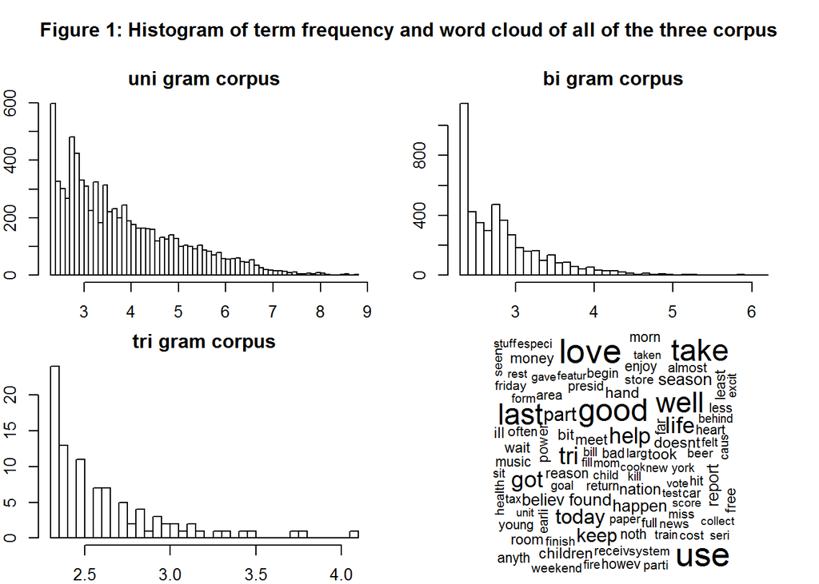

# Conclusions

Some of the takeaways from the exploratory analysis are listed below; - How will we predict next? Hierarchical local regression model might be good fit based on exploratory analysis. - What about removing of stop words. Semantic value influenced us to remove stop words but what happens when it is likely to be typed or desired by the users.

This concludes the exploratory analysis and i will be starting to work towards building the Shinny Application the game of word prediction. Best effort would be used to come up with most accurate predictive application.